# Homework 1

- Show All Code
- Hide All Code
- View Source

Author

Fahad Nawaz | 23201736

Published

June 4, 2025

# Exploring the Diamonds Dataset

## Introduction

The **`diamonds`** dataset, available in the *ggplot2* package, comprises detailed information on over 50,000 diamonds, including their prices and physical attributes. This analysis investigates the relationship between carat (a measure of weight) and price, utilizing a scatter plot to visually assess underlying patterns and potential trends in the data.

## Descriptive Statistics

Below are the summary statistics for the two key variables examined in this analysis:

```r
library(ggplot2)
library(dplyr)
# Display summary statistics of carat and price columns
summary(select(diamonds, carat, price))
```

```
     carat            price
 Min.   :0.2000   Min.   :  326
 1st Qu.:0.4000   1st Qu.:  950
 Median :0.7000   Median : 2401
 Mean   :0.7979   Mean   : 3933
 3rd Qu.:1.0400   3rd Qu.: 5324
 Max.   :5.0100   Max.   :18823
```

### Comments

- Most diamonds are small, with a median weight of 0.7 carats.
- The average price is $3,933, but the median is lower at $2,401, indicating a right-skewed distribution.
- Prices range widely—from $326 to $18,823, suggesting high variability.
- A few large diamonds (up to 5.01 carats) significantly increase the average price.
- The increase in price with carat is non-linear—larger diamonds cost disproportionately more.

## Carat vs. Price Plot

The following scatter plot illustrates the relationship between diamond carat weight and price. A scatter plot is useful here because it allows us to visually assess how price changes with carat, detect patterns or trends, and identify any potential outliers or clusters in the data.

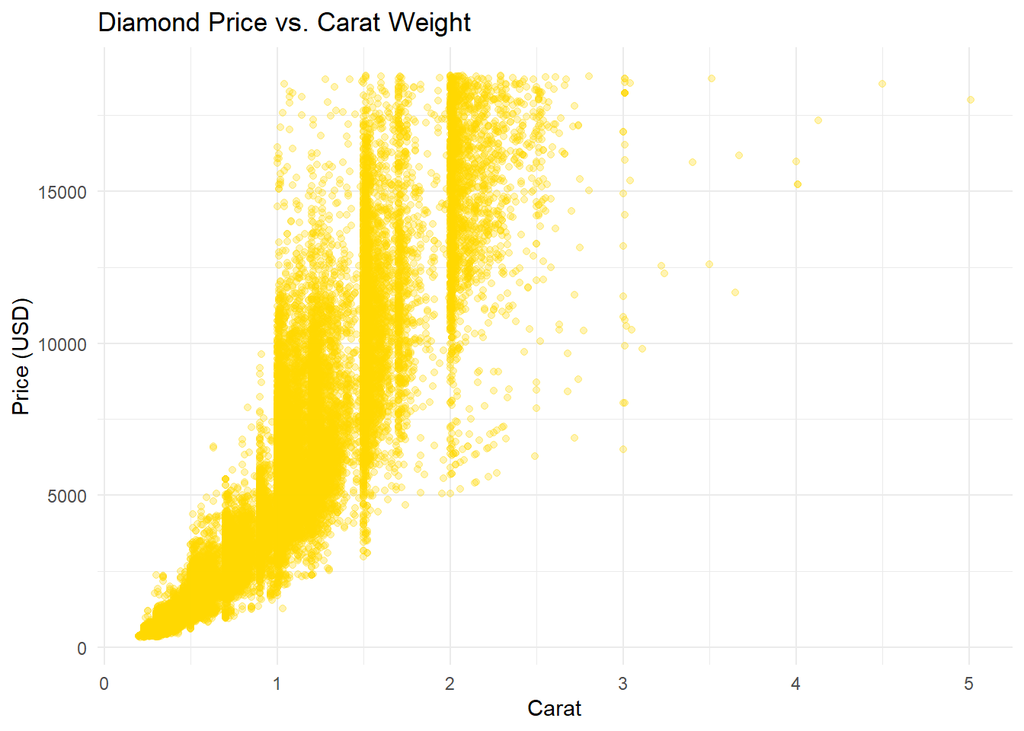

```r
# Create scatter plot using ggplot2
ggplot(diamonds, aes(x = carat, y = price)) +
  geom_point(alpha = 0.3, color = "gold") +
  labs(
    title = "Diamond Price vs. Carat Weight",
    x = "Carat",
    y = "Price (USD)"
  ) +
  theme_minimal()
```